# Analyzing Regional Trends in Influenza-Like Illness (ILI) in Kenya: A Quantitative Epidemiology Case Study

Author: Sandra Korir

April 24th, 2025

## Introduction

This analysis explores trends in Influenza-Like Illnesses (ILI) across various counties in Kenya in the years 2023-2024, in the epidemiological weeks 1-5.  
The data provided includes: records on ILI percentages, the population for different age groups, and county-specific details. The main objective is to evaluate temporal and county-specific ILI trends and interpret the findings to inform public health decisions. Specifically, the aim is to compute the mean ILI percentage per county per year, analyze the weekly trend of ILI, calculate incidence rates, and compare ILI percentages across counties. Results from this analysis will help identify patterns and inform potential public health responses.

## Descriptive analysis

First, we compute the mean ILI percentage for each county per year and visualize the ILI trends over the weeks.

### Mean ILI percentage per county per year

```python
#libraries
import pandas as pd
import matplotlib.pyplot as plt
import seaborn as sns
import numpy as np
from scipy import stats

#plot style
sns.set(style="whitegrid")
```

```python
# Loading the CSV into a DataFrame
ili_data = pd.read_csv("Epi_Task_Data.csv")

# Viewing the first few rows
ili_data.head()
```

|  | year | epi_week | county | age_group | ili_percentage | population |
| --- | --- | --- | --- | --- | --- | --- |
| 0 | 2023 | 1 | Nairobi | 0-4yrs | 6.1 | 3452 |
| 1 | 2024 | 1 | Nairobi | 0-4yrs | 3.2 | 3658 |
| 2 | 2023 | 2 | Nairobi | 0-4yrs | 4.5 | 3043 |
| 3 | 2024 | 2 | Nairobi | 0-4yrs | 4.9 | 2765 |
| 4 | 2023 | 3 | Nairobi | 0-4yrs | 4.6 | 6975 |

```python
#calculating mean ILI pecentage. Group data by county and year.
mean_ili= ili_data.groupby(['county', 'year']) ['ili_percentage'].mean().reset_index()

# Rounding off values
mean_ili['ili_percentage'] = mean_ili['ili_percentage'].round(2)

# result
mean_ili.head()
```

|  | county | year | ili_percentage |
| --- | --- | --- | --- |
| 0 | Kakamega | 2023 | 4.06 |
| 1 | Kakamega | 2024 | 4.54 |
| 2 | Kiambu | 2023 | 3.90 |
| 3 | Kiambu | 2024 | 3.70 |
| 4 | Kisumu | 2023 | 4.06 |

### Visualization of ILI weekly trends across counties

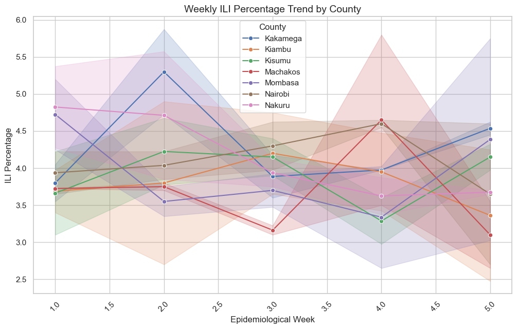

```python
# Grouping by year, epi-week, and county to get the mean ILI percentage per week and county
weekly_trends = ili_data.groupby(['year', 'epi_week', 'county'])['ili_percentage'].mean().reset_index()

# building the plot
plt.figure(figsize=(12, 7))
sns.lineplot(data=weekly_trends, x='epi_week', y='ili_percentage', hue='county', marker='o')

# labels and title
plt.title('Weekly ILI Percentage Trend by County', fontsize=14)
plt.xlabel('Epidemiological Week', fontsize=12)
plt.ylabel('ILI Percentage', fontsize=12)
plt.xticks(rotation=45)
plt.legend(title='County')

# displaying the plot
plt.show()
```

The ILI weekly trend plot across counties from epi-weeks 1-5 shows relatively stable levels of the illnesses at the beginning of the year.

Influenza-Like Illnesses seemed to have increased and peaked in epi-weeks 2 and 4. In epi-week 2, ILI cases rose in most counties, were the highest in Kakamega, but had dropped in Nakuru and Mombasa. In epi-week 4, ILI cases peaked in Machakos and Nairobi, but dropped in Kisumu and Mombasa.

## Computing Epidemiological Measures

This section analyses incidence rates across Kakamega, Kisumu, and Nakuru. Then, using ANOVA, compares ILI percentages across these counties.

### Incidence rates per 100,000 population across Kakamega, Kisumu, and Nakuru

```python
# Selecting counties
ili_data= pd.read_csv("Epi_Task_Data.csv")
selected_counties = ['Kakamega', 'Kisumu', 'Nakuru']
filtered_data = ili_data[ili_data['county'].isin(selected_counties)].copy()

# To calculate incidence rate:
filtered_data['incidence_rate'] = (
    filtered_data['ili_percentage'] / 100) * 100000

# Results
print(filtered_data[['county', 'year', 'epi_week', 'ili_percentage', 'population', 'incidence_rate']])
```

```
       county  year  epi_week  ili_percentage  population  incidence_rate
20     Kisumu  2023         1             3.5        3908          3500.0
21     Kisumu  2024         1             1.3        2647          1300.0
22     Kisumu  2023         2             3.7        2233          3700.0
23     Kisumu  2024         2             5.8        4029          5800.0
24     Kisumu  2023         3             6.8        1519          6800.0
..        ...   ...       ...             ...         ...             ...
275  Kakamega  2024         3             6.0        3554          6000.0
276  Kakamega  2023         4             4.7        3300          4700.0
277  Kakamega  2024         4             2.1        9860          2100.0
278  Kakamega  2023         5             6.1        7747          6100.0
279  Kakamega  2024         5             5.8        3411          5800.0

[120 rows x 6 columns]
```

```python
#the mean incidence rate per county per 100,000 population
incidence_summary = (
    filtered_data
    .groupby('county')['incidence_rate']
    .mean()
    .reset_index()
)

#result
print(incidence_summary)
```

```
     county  incidence_rate
0  Kakamega          4300.0
1    Kisumu          3895.0
2    Nakuru          4155.0
```

### Comparing ILI percentages across Kakamega, Kisumu, and Nakuru

```python
# A one-way ANOVA
Kakamega_data = filtered_data[filtered_data['county'] == 'Kakamega']['ili_percentage']
Kisumu_data = filtered_data[filtered_data['county'] == 'Kisumu']['ili_percentage']
Nakuru_data = filtered_data[filtered_data['county'] == 'Nakuru']['ili_percentage']

# Combining data for ANOVA
data_to_compare = [Kakamega_data, Kisumu_data, Nakuru_data]

# Performing ANOVA
f_statistic, p_value = stats.f_oneway(*data_to_compare)

# Results
print("F-statistic:", f_statistic)
print("P-value:", p_value)
```

```
F-statistic: 0.7770842041341016
P-value: 0.46210263265067264
```

## Findings

According to the ILI weekly trend plot,Influenza-Like Ilnesses peaked in epi-weeks 2 and 4. Though the peaks are generalized, some counties experienced sharper increases, and others, drops even when others had peaks. The fact that ILI seasons varies across counties in these weeks highlights the need to conduct surveillance continuously, even during traditionally low transmission periods

On comparing ILI Incidence rates per 100,000 population across the selected counties (Kakamega, Kisumu, and Nakuru), the result is that Kakamega had the highest mean incident rate, followed by Nakuru and then Kisumu. There is a slight regional variation in disease burden when you look at the incidence numbers. However, An ANOVA test, where F-statistic is 0.7770842041341016 and P-value is 0.46210263265067264, shows that there is no statistically significant difference in ILI percentages across the three counties. This means that the average burden of ILI was relatively similar across these three counties during the study period.

These trends imply early-year seasonality in ILI transmission across the sampled counties. Certain counties may require targeted intervention. To help reduce the ILI burden, public health responses could include: strengthened and continuous ILI surveillance, more preventive campaings, and public awareness; especially before anticipated peak weeks and in more affected regions like Kakamega.